# CNN_Keras_lab_1

**a. To run this notebook in Google Colab, open the notebook in Colab [[this link]](https://colab.research.google.com/github/NBISweden/workshop-neural-nets-and-deep-learning/blob/master/session_convolutionalNeuralNetworks/Labs/CNN_Keras_lab_1.ipynb), select GPU as execution type, then run the following code:**

```python
%cd /content
!git clone https://github.com/NBISweden/workshop-neural-nets-and-deep-learning
%cd /content/workshop-neural-nets-and-deep-learning/session_convolutionalNeuralNetworks/Labs/
!unzip data.zip
```

**b. To run this notebook locally on Jupyter Notebook, use the following command:**

```
curl -o CNN_Keras_lab_1.ipynb https://raw.githubusercontent.com/NBISweden/workshop-neural-nets-and-deep-learning/master/session_convolutionalNeuralNetworks/Labs/CNN_Keras_lab_1.ipynb
```

or download the page from [here](https://raw.githubusercontent.com/NBISweden/workshop-neural-nets-and-deep-learning/master/session_convolutionalNeuralNetworks/Labs/CNN_Keras_lab_1.ipynb)

# CNN Lab 1: Classification of Human Blood Cells using Convolutional Neural Networks

For this lab, we use the image set [Human White Blood Cells (BBBC045v1)](https://bbbc.broadinstitute.org/BBBC045) from the Broad Bioimage Benchmark Collection [Ljosa et al., Nature Methods, 2012].

Using fluorescence staining [[Label‐Free Identification of White Blood Cells Using Machine Learning (Nassar et. al)](https://www.ncbi.nlm.nih.gov/pmc/articles/PMC6767740/)], each blood cell has been classified into one of 5 categories:

- **B cells** (lymphocytes),
- **T cells** (lymphocytes),
- **eosinophils**,
- **monocytes**,
- **neutrophils**.

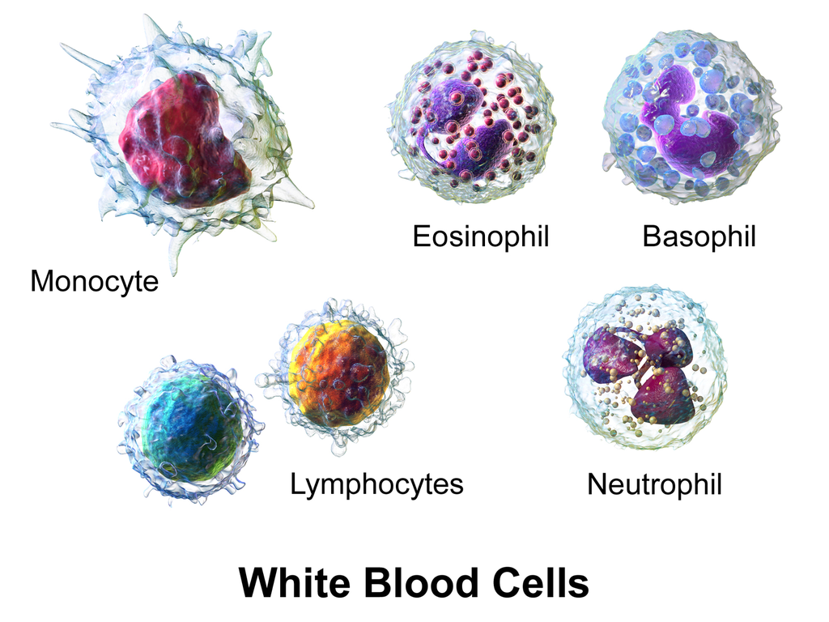

*(Illustration from [Wikipédia](https://en.wikipedia.org/wiki/White_blood_cell))*

## Brightfield dataset

For this lab, we only kept Brightfield images and cropped them into small grayscale patches of 32x32 pixels:

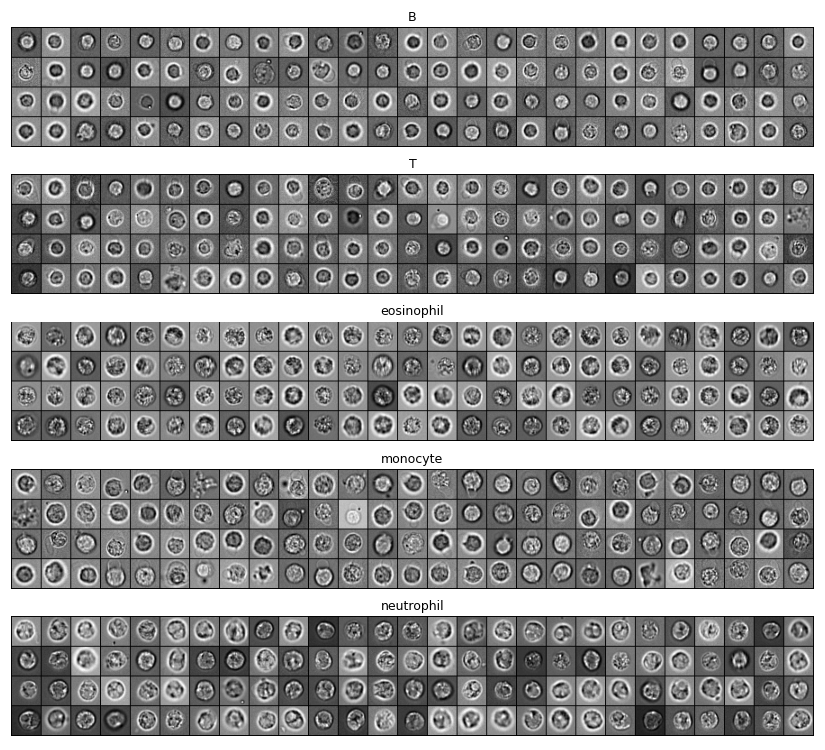

These patches are in the **data/bloodcells_small/** folder, splitted into **testing** and **training** sets. In each set, images are splitted according to their categories:

```
└── data
    └── bloodcells_small
        ├── test
        │   ├── B
        │   ├── T
        │   ├── eosinophil
        │   ├── monocyte
        │   └── neutrophil
        └── train
            ├── B
            ├── T
            ├── eosinophil
            ├── monocyte
            └── neutrophil
```

Our goal is to use convolutional neural networks to automatically classify blood cells into one of the five categories, using only the 32x32 pixels brightfield images.

## First we import useful modules like numpy and Keras layers:

```python
import numpy as np

from tensorflow.keras.models import Sequential, Model

from tensorflow.keras.layers import Conv2D, MaxPooling2D, Dense, Flatten
from tensorflow.keras.layers import BatchNormalization, Dropout, Activation, Input

from tensorflow.keras.preprocessing.image import ImageDataGenerator
from tensorflow.keras.optimizers import Adam

# cnn_helper contains some useful functions for this lab

import cnn_helper
```

# Loading the data in generators

We use Keras functions [`ImageDataGenerator`](https://keras.io/api/preprocessing/image/#imagedatagenerator-class) and [`flow_from_directory`](https://keras.io/api/preprocessing/image/#flowfromdirectory-method) to create generators for the training and testing datasets.

```python
# create a data generator
datagen = ImageDataGenerator(
    rescale=1./255,
    samplewise_center=True,
    samplewise_std_normalization=True
)

print ("Loading training dataset as a generator")
train_generator = datagen.flow_from_directory(
    # You can also try 'data/mnist/train/' which contains digits of size 28x28
    directory='data/bloodcells_small/train/',
    # We use categorical classes, which means that classes will be one-hot encoded:
    class_mode='categorical',
    batch_size=8,
    target_size=(32, 32),
    shuffle=False,
    color_mode="grayscale")

print ("Loading testing dataset as a generator")
test_generator = datagen.flow_from_directory(
    directory='data/bloodcells_small/test/',
    # We use categorical classes, which means that classes will be one-hot encoded:
    class_mode='categorical',
    batch_size=8,
    target_size=(32, 32),
    shuffle=False,
    color_mode="grayscale")
num_classes = 5
input_shape = 32
```

```python
# Uncomment to try on the nmist dataset instead of the bloodcells
'''
# create a data generator
datagen = ImageDataGenerator()

train_generator = datagen.flow_from_directory(
    directory='data/mnist/train/',
    class_mode='categorical',
    batch_size=8,
    target_size=(28, 28),
    shuffle=False,
    seed=42,
    color_mode="grayscale")
test_generator = datagen.flow_from_directory(
    directory='data/mnist/test/',
    class_mode='categorical',
    batch_size=8,
    target_size=(28, 28),
    shuffle=False,
    seed=42,
    color_mode="grayscale")
num_classes = 10
input_shape = 28

print ("Images per class in training:", cnn_helper.getClassSizes(train_generator))
print ("Images per class in testing:", cnn_helper.getClassSizes(test_generator))
'''
```

```python
print ("Images per class in training:", cnn_helper.getClassSizes(train_generator))
print ("Images per class in testing:", cnn_helper.getClassSizes(test_generator))
```

We can now check that the generators deliver our data:

```python
import random
import matplotlib.pyplot as plt

num_images = 5

for i in range(num_images):
    # We select a random batch of the generator
    batch_index = random.randrange(len(train_generator))
    images,categories= train_generator[batch_index]

    # Images are in the shape 32x32x1 and we need 32x32 to be display, so we squeeze the image:
    image = np.squeeze(images[0])

    print ("Category (one-hot encoded):", categories[0])
    print ("Image shape:", image.shape)
    plt.imshow(image)
    plt.show()
```

# Training the model

## A first CNN model

We can start by building a simple convolutional network with one convolutional layer followed by one max-pooling layer.

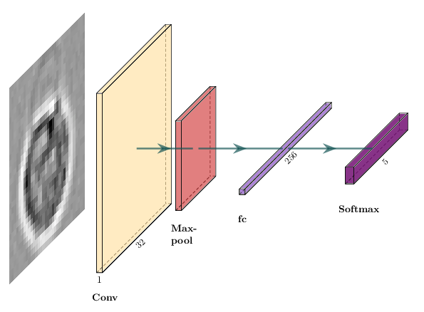

```python
num_filters = 1
filter_size = 2
pool_size = 2

# Build the model.
model = Sequential([
  Conv2D(num_filters, filter_size, input_shape=(input_shape,input_shape,1)),
  MaxPooling2D(pool_size=pool_size),
  Flatten(),
  Dense(num_classes, activation='softmax'),
])

print (model.summary())

# Compile the model.
model.compile(
  'adam',
  loss='categorical_crossentropy',
  metrics=['accuracy'],
)
```

### Train the model on our data from the generator:

```python
model.fit(
  train_generator,
  epochs=5,
  validation_data=test_generator,
)
```

```python
# get random batch of images
batch_index = random.randrange(len(test_generator))
images, categories = test_generator[batch_index]

# compute predictions for the batch
predictions = model.predict(images)

# display predictions using argmax
print(np.argmax(predictions, axis=1))

# compare predictions with ground truth
print (np.argmax(categories, axis=1))
```

We can also plot confusion matrix of the whole generator, using the home-made function:

```
cnn_helper.plot_confusion_matrix_from_generator (model, generator)
```

```python
print ("Test set:")
cnn_helper.plot_confusion_matrix_from_generator (model, test_generator)
```

# Extensions

We can now modify our network to improve the accuracy of our classification.

### Network depth

You can add more convolutional and max-pooling layers, and change the number of features in each convolutional layer.

For example, here are two iterations of convolutional layer plus max-pooling, with 16 and 32 features respectively, and a kernel size of 3:

```
model = Sequential([
    Conv2D(16, kernel_size=3, input_shape=(input_shape,input_shape,1)),
    MaxPooling2D(pool_size=2),
    Conv2D(32, kernel_size=3),
    MaxPooling2D(pool_size=2),
    [...]
])
```

### Dropout

Dropout layers can prevent overfitting. You can add dropout layers after max-pooling. A dropout of 20% is a good starting point.

```
model = Sequential([
    [...]
    Dropout(0.2),
    [...]
])
```

### Fully-connected Layers

Most CNNs use multiple fully-connected layers before the final softmax layer. You can add fully-connected layers using:

```
model = Sequential([
    [...]
    Dense(64, activation='relu'),
    [...]
])
```

### Convolution Parameters

Try to add an activation function to the convelutional layers (`activation='relu'`), and play with other parameters such as `strides` and `padding` (see details [here](https://keras.io/api/layers/convolution_layers/convolution2d/)).

```
model = Sequential([
    [...]
    Conv2D(
        num_filters,
        filter_size,
        input_shape=(32, 32, 1),
        strides=2,
        padding='same',
        activation='relu',
    ),
    [...]
])
```

### Learning Rate

You can change the learning rate of the Adam optimizer:

```
model.compile(
  optimizer = Adam(learning_rate=0.0001),
  [...]
)
```

### Example of more advanced convolutional neural network:

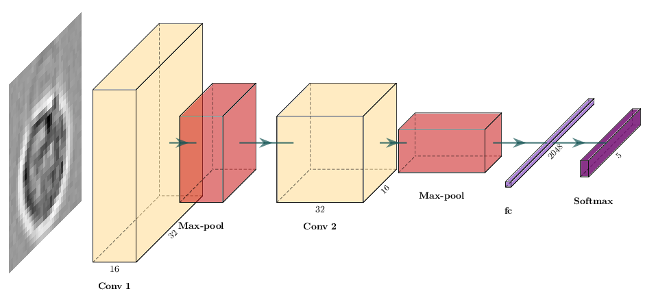

```python
num_filters = 16
# Create the model
model = Sequential([
    Conv2D(num_filters, kernel_size=(3, 3), activation='relu', input_shape=(input_shape,input_shape,1)),
    BatchNormalization(),
    MaxPooling2D(pool_size=(2, 2)),
    Dropout(0.2),
    Conv2D(num_filters*2, kernel_size=(3, 3), activation='relu'),
    MaxPooling2D(pool_size=(2, 2)),
    Dropout(0.2),
    Flatten(),
    Dense(num_filters*8, activation='relu'),
    Dense(num_classes, activation='softmax'),
])

print (model.summary())

# Compile the model.
model.compile(
  optimizer = Adam(learning_rate=0.0001),
  loss      = 'categorical_crossentropy',
  metrics   = ['accuracy'],
)
```

### Train the model:

```python
model.fit(
  train_generator,
  epochs=5,
  validation_data=test_generator,
  #class_weight=cnn_helper.getClassWeights(train_generator)
)
```

```python
#print ("Train set:")
#cnn_helper.plot_confusion_matrix_from_generator (model, train_generator)

print ("Test set:")
cnn_helper.plot_confusion_matrix_from_generator (model, test_generator)
```

# Example of a VGG16 network

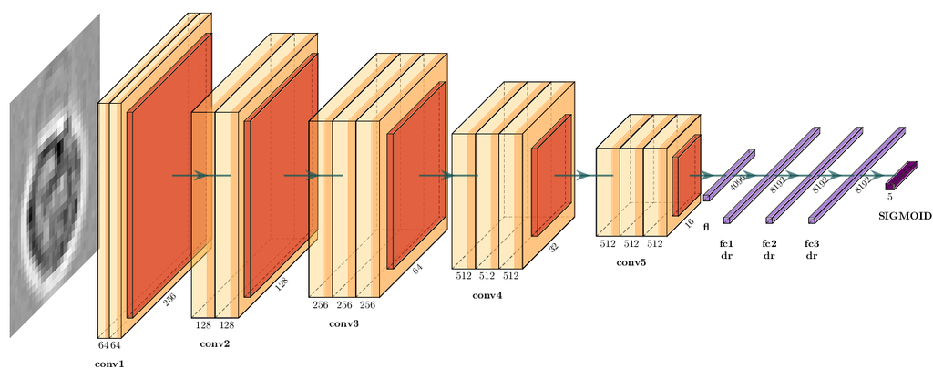

We need to load data in RGB color mode, as VGG16 expects input with 3 layers:

```python
# create a data generator
train_generator_vgg = datagen.flow_from_directory(
    directory='data/bloodcells_small/train/',
    class_mode='categorical',
    batch_size=8,
    target_size=(32, 32),
    shuffle=False,
    color_mode="rgb")
test_generator_vgg = datagen.flow_from_directory(
    directory='data/bloodcells_small/test/',
    class_mode='categorical',
    batch_size=8,
    target_size=(32, 32),
    shuffle=False,
    color_mode="rgb")
```

```python
from tensorflow.keras.applications import VGG16

model = VGG16(
    include_top=False,
    weights=None,
    input_shape=(32, 32, 3),
    pooling=None,
    classifier_activation="softmax",
)

# add new classifier layers
flat1 = Flatten()(model.layers[-1].output)
class1 = Dense(1024, activation='relu')(flat1)
output = Dense(5, activation='softmax')(class1)
# define new model
model = Model(inputs=model.inputs, outputs=output)

print (model.summary())
```

```python
# Compile the model.
model.compile(
  optimizer = Adam(learning_rate=0.0001),
  loss      = 'categorical_crossentropy',
  metrics   = ['accuracy'],
)

model.fit(
  train_generator_vgg,
  epochs=5,
  validation_data=test_generator_vgg
)
```

```python
print ("Train set:")
cnn_helper.plot_confusion_matrix_from_generator (model, train_generator_vgg)

print ("Test set:")
cnn_helper.plot_confusion_matrix_from_generator (model, test_generator_vgg)
```